# zuoye21015

Xiyue Zhu

2021-12-16

## Question

A—21015—2021—09—16  
Use knitr to produce at least 3 examples (texts, figures, tables).

## Answer

texts:利用R语言内置数据集state.x77（其数据意义：美国50个州的八个指标）  
用到的包和函数：  
1. head:输出数据集的前六行。  
2. kable:制作好看的表格。  
3. pheatmap：制作热图。  
4. as.matrix：转化为矩阵  
5. scale：对数据进行中心化和标准化

tables:为了使表格不过大，可以利用head函数输出state.x77的前六行，再使用kable函数制作出表格。

```r
library(knitr)
data1 <- head(state.x77)
kable(data1)
```

|  | Population | Income | Illiteracy | Life Exp | Murder | HS Grad | Frost | Area |
| --- | --- | --- | --- | --- | --- | --- | --- | --- |
| Alabama | 3615 | 3624 | 2.1 | 69.05 | 15.1 | 41.3 | 20 | 50708 |
| Alaska | 365 | 6315 | 1.5 | 69.31 | 11.3 | 66.7 | 152 | 566432 |
| Arizona | 2212 | 4530 | 1.8 | 70.55 | 7.8 | 58.1 | 15 | 113417 |
| Arkansas | 2110 | 3378 | 1.9 | 70.66 | 10.1 | 39.9 | 65 | 51945 |
| California | 21198 | 5114 | 1.1 | 71.71 | 10.3 | 62.6 | 20 | 156361 |
| Colorado | 2541 | 4884 | 0.7 | 72.06 | 6.8 | 63.9 | 166 | 103766 |

figures: 我想要直观的看出这些州的相似性（同时对他们聚类）和指标之间的联系，可以生成每个州和指标的热图。从热图可以很清楚的看出聚类的结果。右边的图例能够说明两者的相关程度，上方Area和Alaska处方块很红，说明相关性很高，但大多数地方颜色偏蓝，呈现出大批量的负相关性。

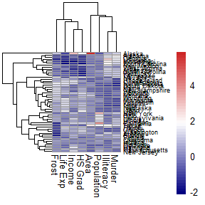

```r
library(pheatmap)
data2 <- as.matrix((scale(state.x77)))
p <- pheatmap(data2,fontsize=10,fontsize_row=7,color=colorRampPalette(c("navy","white","firebrick3"))(50))
```

## Question

A—21015—2021—09—23  
Exercises 3.4, 3.11, and 3.20 (pages 94-96, Statistical Computating with R)

## Answer

3.4 Rayleigh分布的密度函数为：

$f(x)=\frac{x}{\sigma^2}e^{-x^2/(2\sigma^2)}$,

对其积分，可以得到分布函数

$F(x)=\int_{0}^{\infty} \frac{x}{\sigma^2}e^{-x^2/(2\sigma^2)}dx=1-e^{-\frac{x^2}{2\sigma^2}}$，

对于连续函数，想要产生其随机数，可以使用反函数变换法。  
令$U=F_X(X) \sim Uniform(0,1)$，则$X=F_X^{-1}(U)=\sqrt{-2\sigma^2\ln(1-U)}$。  
其产生随机数的具体步骤如下：  
step1: 产生均匀分布的随机数$U$，即$U∼U(0,1)$；  
step2: 利用逆变换产生$X=F_X^{-1}(U)=\sqrt{-2\sigma^2\ln(1-U)}$；  
我分别选取如下$\sigma$,产生随机数。

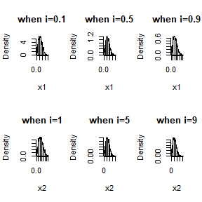

```r
par(mfrow=c(2,3))
n <- 1000
for (i in seq(0.1, 1, by=0.4)){
  sigma <- i
  u <- runif(n)  #step1
  x1 <- sqrt(-2* sigma^2 * log(1-u)) #step2
  t <- seq(0,100,.01)
  hist(x1,prob=TRUE,main=paste ("when i=", as.character(i), sep = "")) #对标题进行修改
  lines(t, t/(sigma^2)*exp(-t^2/(2*sigma^2)))
}


for (i in seq(1, 10, by=4)){
  sigma <- i
  u <- runif(n)  #step1
  x2 <- sqrt(-2* sigma^2 * log(1-u)) #step2
  t <- seq(0,100,.01)
  hist(x2,prob=TRUE,main=paste ("when i=", as.character(i), sep = ""))
  lines(t, t/(sigma^2)*exp(-t^2/(2*sigma^2)))
}
```

我发现，在不同参数下，直方图和理论模型拟合较好。

3.11 题目需要我们生成N(0,1)和N(3,1)的混合分布，并对混合分布的系数做不断变化，视其是否可以改变成双峰。sample函数可以控制p的取值概率。

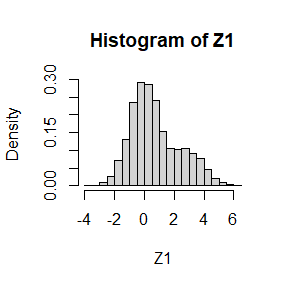

```r
n <- 1e4 #生成1000个随机数
X1 <- rnorm(n,0,1)
X2 <- rnorm(n,3,1)
p <- sample(c(0,1),n,replace=TRUE,prob=c(0.25,0.75)) #控制 p1=0.75 和 p2 = 1 − p1=0.25
Z1 <- p*X1+(1-p)*X2 #生成混合分布
hist(Z1,prob=TRUE) #做直方图
```

```r
out1 <- list()
for (i in 1:1000){
  t <- 10
  alpha <- 4
  beta <- 3
  lambda <- 5
  nt <- rpois(1,lambda*t)
  y <- rgamma(nt,alpha,beta)
  xt<- sum(y)
  out1[[i]] <- xt
}
out1 <- as.vector(unlist(out1))

Ext <- mean(out1)
Varxt <- var(out1)
Extl <- lambda*t*alpha/beta
Varxtl <- lambda*t*(alpha/beta^2+(alpha/beta)^2)
diffExt <- Extl-Ext
diffvarxt <- Varxtl-Varxt
print(diffExt)
```

```
## [1] 0.6527664
```

```r
print(diffvarxt)
```

```
## [1] 5.81818
```

通过多次模拟，可以发现此参数下模拟的均值和方差与理论中的相差很小。

下面我随机变换参数，

```r
out1 <- list()
for (i in 1:1000){
  t <- 10
  alpha <- 2
  beta <- 6
  lambda <- 15
  nt <- rpois(1,lambda*t)
  y <- rgamma(nt,alpha,beta)
  xt<- sum(y)
  out1[[i]] <- xt
}
out1 <- as.vector(unlist(out1))

Ext <- mean(out1)
Varxt <- var(out1)
Extl <- lambda*t*alpha/beta
Varxtl <- lambda*t*(alpha/beta^2+(alpha/beta)^2)
diffExt <- Extl-Ext
diffvarxt <- Varxtl-Varxt
print(diffExt)
```

```
## [1] 0.1859208
```

```r
print(diffvarxt)
```

```
## [1] 0.3343366
```

通过多次模拟，可以发现此参数下模拟的均值和方差与理论中的相差很小，但是也不排除某些模拟时，方差相差略大，但是偏差基本不大于1.5。因此，可以认为在不同参数下，模拟的均值和方差与理论中的相差很小，均值模拟表现得更好。

## Question

A—21015—2021—09—30  
Exercises 5.4, 5.9, 5.13, and 5.14 (pages 149-151, Statistical Computing with R).

## Answer

5.4 已知$Beta(3,3)$的分布函数$F(x)=\int_{0}^{x} \frac{1}{Beta(3,3)}t^2(1-t)^2dt=E_{t}[x\frac{1}{Beta(3,3)}t^2(1-t^2)]$，  
取$g(x)=x\frac{1}{Beta(3,3)}t^2(1-t^2)$，$t服从U(0,x)$。  
flowchart如下：  
1.从$U(0,x)$生成独立同分布的$x_1, x_2...,x_m$，  
2.计算$\overline{g(x)} = \frac{1}{m} \sum_{1}^{m}g(x)$，  
3.得到$\hat{\theta}=(x-0)\overline{g(x)}。$

```r
theta.hat <- rep(0,9)
B <- beta(3,3)
m <- 1000
for (t in seq(1,9,by=1)){
  y <- runif(m,0,t/10)  #t是从0.1-0.9的
  theta.hat[t] <- mean(t/10*(y^4-2*y^3+y^2))/B
}
print(theta.hat)
```

```
## [1] 0.008198896 0.055825037 0.166985107 0.310694521 0.499520136 0.712447706
## [7] 0.832560922 0.965915433 0.968179340
```

```r
t <- seq(0.1,0.9,0.1)
p <- pbeta(t,3,3)
diff <- theta.hat-p
print(p)
```

```
## [1] 0.00856 0.05792 0.16308 0.31744 0.50000 0.68256 0.83692 0.94208 0.99144
```

```r
print(diff)
```

```
## [1] -0.0003611039 -0.0020949625  0.0039051074 -0.0067454791 -0.0004798640
## [6]  0.0298877060 -0.0043590782  0.0238354332 -0.0232606596
```

可以发现，两者十分接近。

5.9 瑞利分布积分：  
$F(x)=\int_{0}^{x} \frac{t}{\sigma^2}e^{-t^2/(2\sigma^2)}dt=E[x\frac{t}{\sigma^2}e^{-t^2/(2\sigma^2)}]$  
所以简单的估计量:  
$\frac{x+x'}{2}= \frac{1}{m} \sum_{1}^{m} x \frac{u_j}{\sigma^2}e^{-(u_j)^2/(2\sigma^2)}$  
对偶估计量:  
$\frac{x_1+x_2}{2}= \frac{1}{m} \sum_{1}^{m/2} \{ x\frac{u_j}{\sigma^2}e^{-(u_j)^2/(2\sigma^2) }+ x\frac{ (x-u_j)}{\sigma^2}e^{-(x-u_j)^2/(2\sigma^2)} \}$  
此处我们取$\sigma=2$做一下模拟：

```r
MC.Phi <- function(x, R = 10000, antithetic = TRUE) {
  u <- runif(R/2,0,x)
  sigma <- 2
  if (!antithetic) v <- runif(R/2) else v <- 1 - u
  u <- c(u, v)
  cdf <- numeric(length(x))
  for (i in 1:length(x)) {
    g <- x[i] * u / (sigma^2) * exp(-(u)^2 / 2 /(sigma^2))
    cdf[i] <- mean(g)
  }
  cdf
}
m <- 1000
MC1 <- MC2 <- numeric(m)
x <- 1.95
for (i in 1:m) {
  MC1[i] <- MC.Phi(x, R = 1000, anti = FALSE)
  MC2[i] <- MC.Phi(x, R = 1000)
}

print(c(var(MC1),var(MC2),var(MC2)/var(MC1)))
```

```
## [1] 2.374013e-05 4.003397e-06 1.686341e-01
```

可以发现对偶比非对偶的方差减少了很多。

[figure not shown]

```r
x <- seq(1, 5, .01)
w <- 2

g <-  x^2 * exp(-x^2/2) / sqrt(2 * pi)
f0 <- rep(1,length(x))
f1 <- x*exp(-x^2/2)/exp(1)^(-1/2)
f2 <- x^{-6/5}/5
gs <- c(expression(g(x)==x^2*e^{-x^2/2}/sqrt(2*pi)),
        expression(f[0](x)==1),
        expression(f[1](x)==x*e^{-x^2/2}/e^{-1/2}),
        expression(f[2](x)==x^{-6/5}/5))
#for color change lty to col
par(mfrow=c(1,2))
#figure (a)
plot(x, g, type = "l", ylab = "",
     ylim = c(0,2), lwd = w,col=1,main='(A)')
lines(x, f0, lty = 2, lwd = w,col=2)
lines(x, f1, lty = 3, lwd = w,col=3)
lines(x, f2, lty = 4, lwd = w,col=4)
legend("topright", legend = gs,
       lty = 1:4, lwd = w, inset = 0.02,col=1:4)

#figure (b)
plot(x, g/f0, type = "l", ylab = "",
     ylim = c(0,3.2), lwd = w, lty = 2,col=2,main='(B)')
lines(x, g/f1, lty = 3, lwd = w,col=3)
lines(x, g/f2, lty = 4, lwd = w,col=4)
legend("topright", legend = gs[-1],
       lty = 2:4, lwd = w, inset = 0.02,col=2:4)
```

接下来，我们来判断在估计$g(x)$积分时，谁的方差更小。

```r
library(knitr)
m <- 1000
est <- sd <- numeric(3)
g <- function(x) {
  exp(-x^2/2) * x^2/ sqrt(2*pi)
}
x <- runif(m) #using f0
fg <- g(x)
est[1] <- mean(fg)
sd[1] <- sd(fg)

x <- runif(m) #using f1
fg <- g(x) / (x*exp(-x^2/2)/exp(1)^(-1/2))
est[2] <- mean(fg)
sd[2] <- sd(fg)

x <- runif(m) #using f2
fg <- g(x) / (x^(-6/5)/5)
est[3] <- mean(fg)
sd[3] <- sd(fg)

res <- rbind(est=round(est,3), sd=round(sd,3))
colnames(res) <- paste0('f',0:2)
kable(res)
```

|  | f0 | f1 | f2 |
| --- | --- | --- | --- |
| est | 0.102 | 0.124 | 0.336 |
| sd | 0.078 | 0.071 | 0.360 |

可以发现$f_1$的方差比$f_2$小。

5.14 用5.13中的函数可以估计值，我试图挑选以下更多close的函数（如13中），但是似乎我找到的函数都不能很好的计算出结果，因此我采用另一种importance sampling方法。  
已知$\int_{1}^{\infty} \frac{x^2}{\sqrt{2\pi}}e^{-x^2/2}dx=\int_{0}^{\infty} \frac{x^2}{\sqrt{2\pi}}e^{-x^2/2}dx-\int_{0}^{1} \frac{x^2}{\sqrt{2\pi}}e^{-x^2/2}dx=\frac{1}{2}-\int_{0}^{1} \frac{x^2}{\sqrt{2\pi}}e^{-x^2/2}dx$，  
找一个函数$f(x)=xe^{-x^2/2}$，计算$\int_{0}^{1} xe^{-x^2/2}dx=1-\frac{1}{\sqrt{e}}$，  
因此可以转变原问题为$\frac{1}{2}-\int_{0}^{1} \frac{x}{\sqrt{2\pi}}(1-\frac{1}{\sqrt{e}})\frac{xe^{-x^2/2}}{1-\frac{1}{\sqrt{e}}}dx=\frac{1}{2}-E(\frac{x}{\sqrt{2\pi}}(1-\frac{1}{\sqrt{e}})$，其中$x$的密度函数为$\frac{xe^{-x^2/2}}{1-\frac{1}{\sqrt{e}}}$。  
如何计算$\frac{1}{\sqrt{2\pi}}(1-\frac{1}{\sqrt{e}})E(x)$，可以利用之前学过的反函数法，令$\int_{0}^{1}\frac{xe^{-x^2/2}}{1-\frac{1}{\sqrt{e}}}dx=\frac{1-e^{-x^2/2}}{1-\frac{1}{\sqrt{e}}}=U$，则$x=\sqrt{-2ln(1-U+U/\sqrt{e})}$。

```r
n <- 1000
u <- runif(n)
x <- sqrt(-2* log(1-u+u/sqrt(exp(1))))
theta <- 1/2-mean(x)/sqrt(2*pi)*(1-1/sqrt(exp(1))) #根据原公式计算值
print(theta)
```

```
## [1] 0.4008059
```

## Question

A-21015-2021-10-14  
Exercises 6.5 and 6.A (page 180-181, Statistical Computing with R)  
If we obtain the powers for two methods under a particular simulation setting with 10,000 experiments: say, 0.651 for one method and 0.676 for another method. We want to know if the powers are different at 0.05 level.  
1. What is the corresponding hypothesis test problem?  
2. What test should we use? Z-test, two-sample t-test, paired-t test or McNemar test? Why?  
3. Please provide the least necessary information for hypothesis testing.

## Answer

6.5 题目让我们进行均值$t$检验，服从：$\displaystyle{\frac{\overline{x}-u}{s/\sqrt{n}}} \sim t(n)$。  
因此$u=\overline{x} - \displaystyle{\frac{t(n) s}{\sqrt{n}}}$，其中$x \sim \chi^2(2)$。

```r
n <- 20
s <- 0
x1 <- numeric(1000)
x2 <- numeric(1000)
alpha <- .05
for (i in 1:1000){
  x <- rchisq(n,df=2)
  x1[i] <- mean(x)- qt(1-alpha/2,df=n-1)*sd(x)/sqrt(n)
  x2[i] <- mean(x)+ qt(1-alpha/2,df=n-1)*sd(x)/sqrt(n)
  if (x1[i] < 2  && 2< x2[i])
  s <- s+1
}
print(s/1000)
```

```
## [1] 0.928
```

可以发现置信区间并没有非常靠近理论值95%，但相差不大。相比example6.4的推广6.5，x服从正态分布的结果明显好于x服从卡方分布。相比example6.4的推广example6.6，在x服从分布一样的条件下，均值检验的置信区间好于方差的检验。

6.A 题目要解决的问题如下：在样本服从$\chi^2(1)$，$U(0,2)$，$exp(1)$。  
1.是否$t$检验的empirical Type I error rate = $\alpha$。  
2.假设检验$H_0: u=u_0$。  
情况1：$x \sim \chi^2(1)$

```r
set.seed(12)
n <- 100 #任意抽取n个样本
alpha <- .05
mu0 <- 1 #经过推导，可以知道卡方的自由度=均值

m <- 1000
p <- numeric(m)
for (j in 1:m) {
  x <- rchisq(n, df=1)
  ttest <- t.test(x, mu = mu0) #做检验
  p[j] <- ttest$p.value
}

p.hat <- mean(p < alpha)
print(p.hat)
```

```
## [1] 0.062
```

可以发现$p$值略大于$\alpha$，接受原假设。

情况2：$x \sim U(0,2)$

```r
set.seed(12)
n <- 100
alpha <- .05
mu0 <- 1 #均匀分布的均值为(a+b)/2

m <- 1000
p <- numeric(m)
for (j in 1:m) {
  x <- runif(n,0,2)
  ttest <- t.test(x, mu = mu0)
  p[j] <- ttest$p.value
}

p.hat <- mean(p < alpha)
print(p.hat)
```

```
## [1] 0.059
```

可以发现$p$略大于$\alpha$，接受原假设。

情况3：$x \sim exp(1)$

```r
set.seed(12)
n <- 100
alpha <- .05
mu0 <- 1 #指数分布的均值为1/lambda

m <- 1000
p <- numeric(m)
for (j in 1:m) {
  x <- rexp(n, 1)
  ttest <- t.test(x, mu = mu0)
  p[j] <- ttest$p.value
}

p.hat <- mean(p < alpha)
print(p.hat)
```

```
## [1] 0.068
```

可以发现$p$值大于$\alpha$，应该接受原假设。

问题:If we obtain the powers for two methods under a particular simulation setting with 10,000 experiments: say, 0.651 for one method and 0.676 for another method. We want to know if the powers are different at 0.05 level.  
1. What is the corresponding hypothesis test problem?  
2. What test should we use? Z-test, two-sample t-test, paired-t test or McNemar test? Why?  
3. Please provide the least necessary information for hypothesis testing.  
解答：  
1. 对应的假设检验问题是：one method服从$B(n,p_1)$，another method服从$B(n,p_2)$，原假设：$p_1=p_2$，备择假设：$p_1 \neq p_2$。  
2. 我认为可以用paired-t-test，把$p_1-p_2=0$视为原假设，$p_1 -p_2 \neq 0$视为备择假设。  
3. 用paired-t-test最大的问题是数据只有一组，没办法做paired-t-test，可以用两种方法多做几组实验，得到$p_1$和$p_2$的更多数据。如果用 two-sample t-test方法，需要验证两样本应近似服从正太分布，且两样本方差也应该近似相等。

## Question

A-21015-2021-10-21 Exercises 6.C (pages 182, Statistical Computating with R).

## Answer

6.C x是每个元素都服从正态分布的n*d的矩阵，funb1d函数计算了$nb_{1,d}/6$。example6.8想要我们检验偏度是否为0。

```r
library(MASS)
n <- c(10, 20, 30, 50)
m <- 100
d <- 3
c <- qchisq(0.95, d*(d+1)*(d+2)/6)
p.reject <- numeric(length(n))

funb1d <- function(x) {
  xbar <- colMeans(x) #每一列的平均值
  sigma <- cov(x)
  b1d <- 0
  for (p in 1:n[i]){
    for (q in 1:n[i]){
       b1d <- b1d +( (x[p,]-xbar) %*% solve(sigma) %*% (x[q,]-xbar)  )^3
    }
  }
  b1d <- b1d/n[i]/6
  return( b1d )
}

for (i in 1:length(n)) {
  test <- numeric(m)
  for (j in 1:m) {
    x <- matrix(rnorm(n[i]*d), nrow = n[i], ncol = d)
    test[j] <- as.integer(funb1d(x) >= c)
  }
  p.reject[i] <- mean(test)
}

p.reject
```

```
## [1] 0.00 0.02 0.01 0.02
```

根据6.10，建立混合分布：$(1-\epsilon)N(u=0, \sigma^2=1)+\epsilon N(u=0,\sigma^2=10)$，并画出经验power曲线。

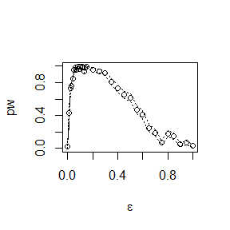

```r
alpha <- .1
n <- 30
m <- 100
d <-3
epsilon <- c(seq(0, 0.15, .01),seq(0.15, 1, .05))
N <- length(epsilon)
pw <- numeric(N)
c <- qchisq(1-alpha, d*(d+1)*(d+2)/6)

funb1d <- function(x) { #原本的
  xbar <- colMeans(x) #每一列的平均值
  COV <- cov(x)
  b1d <- 0
  for (p in 1:n){
    for (q in 1:n){
      b1d <- b1d +( (x[p,]-xbar) %*% solve(COV) %*% (x[q,]-xbar)  )^3
    }
  }
  b1d <- b1d/n/6
  return(b1d )
}

for (j in 1:N) {
  e <- epsilon[j]
  test <- numeric(m)
  for (i in 1:m) {
    sigma <- sample(c(1, 10), replace = TRUE, size = n*d, prob = c(1-e, e))
    x <- matrix(rnorm(n*d, 0, sigma), nrow = n, ncol = d)
    test[i] <- as.integer(funb1d(x) >= c)
  }
  pw[j] <- mean(test)
}

plot(epsilon, pw, type = "b", xlab = bquote(epsilon), ylim = c(0,1))
se <- sqrt(pw * (1-pw) / m)
lines(epsilon, pw+se, lty = 3)
lines(epsilon, pw-se, lty = 3)
```

在$0 < ε < 1$时，最高峰出现在$0.1-0.2$之间。

## Question

A-21015-2021-10-28 Exercises 7.7,7.8,7.9 and 7.B (pages 213, Statistical Computating with R).

## Answer

7.7 题目想要我们用bootstrap估计$\hat{\theta}$的偏差和标准差，其中$\hat{\theta}=\displaystyle{\frac{\hat{\lambda_1}}{\sum_{j=1}^{5}\lambda_j}}$。

```r
library(bootstrap)
library(boot)
lam_hat <- eigen(cov(scor))$values
the_hat <- lam_hat[1] /sum(lam_hat) #原本的\theta统计量
B <- 50

the_b <- numeric(B)
func <- function(dat,d){
     x <- dat[d,]
     lam <- eigen(cov(scor[x,]))$values
     the <- lam[1] /sum(lam)
     return(the)
}

result <- boot(data = cbind(scor$mec,scor$vec,scor$alg,scor$ana,scor$sta),statistic = func,R=B)

the_b <- result$t
round(c(bias_boot=mean(the_b)-the_hat,se_boot=sqrt(var(the_b))),5)
```

```
## bias_boot   se_boot
##  -0.27421   0.01871
```

7.8 题目想要我们用jackknife估计$\hat{\theta}$的偏差和标准差。

```r
n <- nrow(scor)
the_j <- rep(0,n)
for (i in 1:n){
  x <- scor[-i,]
  lam <- eigen(cov(x))$values
  the_j[i] <- lam[1] /sum(lam)
}
bias_jack <- (n-1)*(mean(the_j)-the_hat)
se_jack <-  (n-1)*sqrt(var(the_j)/n)
round(c(bias_jack=(n-1)*(mean(the_j)-the_hat),se_jack=(n-1)*sqrt(var(the_j)/n)),5)
```

```
## bias_jack   se_jack
##   0.00107   0.04955
```

7.9 题目想要我们算出$\hat{\theta}$的95%的分位数和BCa置信区间。

```r
boot.ci(boot.out = result, conf = 0.95, type = c("perc","bca"))
```

[output not shown]

7.B 题目想要我们算出正态分布时样本偏度的三种覆盖率。

```r
mu<-0;n<-100;m<-1e3
library(boot)
set.seed(1)
func <- function(x,i){
  xbar <- mean(x[i])
  m3 <- mean((x - xbar)^3)
  m2 <- mean((x - xbar)^2)
  return( m3 / m2^1.5 )
}
ci.norm<-ci.basic<-ci.perc<-ci.bca<-matrix(NA,m,2)
for(i in 1:m){
  x <-rnorm(n)
  de <- boot(data=x,statistic=func, R = 999)
  ci <- boot.ci(de,type=c("norm","basic","perc"))
  ci.norm[i,]<-ci$norm[2:3];ci.basic[i,]<-ci$basic[4:5]
  ci.perc[i,]<-ci$percent[4:5]
}
round(c(norm = mean(ci.norm[,1]<=mu & ci.norm[,2]>=mu),basic = mean(ci.basic[,1]<=mu & ci.basic[,2]>=mu),perc =mean(ci.perc[,1]<=mu & ci.perc[,2]>=mu),right.norm = sum(ci.norm[,1]>=mu)/m,left.norm = sum(ci.norm[,2]<=mu)/m,right.basic = sum(ci.basic[,1]>=mu)/m,left.basic = sum(ci.basic[,2]<=mu)/m,right.perc = sum(ci.perc[,1]>=mu)/m,left.perc= sum(ci.perc[,2]<=mu)/m ),4)
```

```
##        norm       basic        perc  right.norm   left.norm right.basic
##       0.982       0.981       0.991       0.005       0.013       0.005
##  left.basic  right.perc   left.perc
##       0.014       0.003       0.006
```

题目要求我们算出卡方分布的样本偏度的三种覆盖率。  
由于$var(\chi^2(5))=10$，$\chi^2(5)=GA(5/2,1/2)$， 算出$\chi^2(5)$的理论偏度：$b=v_3/\sigma^3$，$v_3 = 2\alpha/\lambda^{3}$，$\sigma^3 = (\sigma^2)^{1.5} =(10)^{1.5}$。

```r
b <- 2*(5/2)/(1/2)^3 / (10)^{1.5}
set.seed(12)
n<-100
m<-1e3
library(boot)
func <- function(x,i){
  xbar <- mean(x[i])
  m3 <- mean((x - xbar)^3)
  m2 <- mean((x - xbar)^2)
  return( m3 / m2^1.5 )
}
ci.norm<-ci.basic<-ci.perc<-ci.bca<-matrix(NA,m,2)
for(i in 1:m){
  x <- rchisq(n,5)
  de <- boot(data=x,statistic=func, R = 999)
  ci <- boot.ci(de,type=c("norm","basic","perc"))
  ci.norm[i,]<-ci$norm[2:3];ci.basic[i,]<-ci$basic[4:5]
  ci.perc[i,]<-ci$percent[4:5]
}
round(c(norm = mean(ci.norm[,1]<=b & ci.norm[,2]>=b),basic = mean(ci.basic[,1]<=b & ci.basic[,2]>=b),perc =mean(ci.perc[,1]<=b & ci.perc[,2]>=b),right.norm = sum(ci.norm[,1]>=b)/m,left.norm = sum(ci.norm[,2]<=b)/m,right.basic = sum(ci.basic[,1]>=b)/m,left.basic = sum(ci.basic[,2]<=b)/m,right.perc = sum(ci.perc[,1]>=b)/m,left.perc= sum(ci.perc[,2]<=b)/m ),4)
```

```
##        norm       basic        perc  right.norm   left.norm right.basic
##       0.864       0.856       0.852       0.060       0.076       0.087
##  left.basic  right.perc   left.perc
##       0.057       0.036       0.112
```

## Question

A-21015-2021-11-04 1. Exercise 8.2 (page 242, Statistical Computating with R).  
2. Design experiments for evaluating the performance of the NN,energy, and ball methods in various situations.  
Unequal variances and equal expectations  
Unequal variances and unequal expectations  
Non-normal distributions: t distribution with 1 df (heavy-tailed distribution), bimodel distribution (mixture of two normal distributions)  
Unbalanced samples (say, 1 case versus 10 controls)  
Note: The parameters should be chosen such that the powers are distinguishable (say, range from 0.3 to 0.8)

## Answer

8.2 利用双变量Spearman秩相关独立检验作为permutation test。用“Spearman”方法从函数cor中得到Spearman秩相关检验统计量。将permutation test的显著性水平与cor.test的p值在相同样本上进行比较。

```r
v1 <- c(0.1, 0.15, 0.2, 0.25, 0.3, 0.35, 0.4, 0.45, 0.5, 0.55)  #随意选取的数据
v2 <- c(1, 0.95, 0.95, 0.9, 0.85, 0.7, 0.65, 0.6, 0.55, 0.42)
m <- cor.test(v1, v2, alternative = "two.sided", method = "spearman", exact = FALSE)  #m为cor.test检验的结果

R <- 999
v <- c(v1,v2)
K <- 1:20
n <- length(v1)
set.seed(123)
reps <- numeric(R)
t0 <- cor(v1,v2,method = "spearman")
for (i in 1:R){                                        #做permutation test
  k <- sample(K,size=n,replace=FALSE)
  x1 <- v[k]
  y1 <- v[-k]
  reps[i] <- cor(x1,y1,method = "spearman")
}
p <- mean(abs(c(t0,reps)) >= abs(t0))
round(c(p,m$p.value),3)
```

```
## [1] 0.001 0.000
```

Design experiments for evaluating the performance of the NN,energy, and ball methods in various situations.  
1. Unequal variances and equal expectations

```r
library(RANN)
library(boot)
library(Ball)
library(energy)
m <- 100; k<-3; p<-2; set.seed(123)
n1 <- n2 <- 50; R<-999; n <- n1+n2; N = c(n1,n2)
Tn <- function(z, ix, sizes,k) {
  n1 <- sizes[1]; n2 <- sizes[2]; n <- n1 + n2
  if(is.vector(z)) z <- data.frame(z,0);
  z <- z[ix, ];
  NN <- nn2(data=z, k=k+1) # what's the first column?
  block1 <- NN$nn.idx[1:n1,-1]
  block2 <- NN$nn.idx[(n1+1):n,-1]
  i1 <- sum(block1 < n1 + .5); i2 <- sum(block2 > n1+.5)
  (i1 + i2) / (k * n)
}
eqdist.nn <- function(z,sizes,k){
  boot.obj <- boot(data=z,statistic=Tn,R=R,sim = "permutation", sizes = sizes,k=k)
  ts <- c(boot.obj$t0,boot.obj$t)
  p.value <- mean(ts>=ts[1])
  list(statistic=ts[1],p.value=p.value)
}
p.values <- matrix(NA,m,3)
for(i in 1:m){
  x <- matrix(rnorm(n1*p,0,1),ncol=p);
  y <- matrix(rnorm(n2*p,0,1.5),ncol=p);
  z <- rbind(x,y)
  p.values[i,1] <- eqdist.nn(z,N,k)$p.value
  p.values[i,2] <- eqdist.etest(z,sizes=N,R=R)$p.value
  p.values[i,3] <- bd.test(x=x,y=y,num.permutations=999,seed=i*12345)$p.value
}
pow <- colMeans(p.values<0.1) #alpha <- 0.1
print(pow)
```

```
## [1] 0.44 0.67 0.96
```

2. Unequal variances and unequal expectations

```r
m <- 100; k<-3; p<-2; set.seed(12345)
n1 <- n2 <- 50; R<-999; n <- n1+n2; N = c(n1,n2)
Tn <- function(z, ix, sizes,k) {
  n1 <- sizes[1]; n2 <- sizes[2]; n <- n1 + n2
  if(is.vector(z)) z <- data.frame(z,0);
  z <- z[ix, ];
  NN <- nn2(data=z, k=k+1) # what's the first column?
  block1 <- NN$nn.idx[1:n1,-1]
  block2 <- NN$nn.idx[(n1+1):n,-1]
  i1 <- sum(block1 < n1 + .5); i2 <- sum(block2 > n1+.5)
  (i1 + i2) / (k * n)
}
eqdist.nn <- function(z,sizes,k){
  boot.obj <- boot(data=z,statistic=Tn,R=R,sim = "permutation", sizes = sizes,k=k)
  ts <- c(boot.obj$t0,boot.obj$t)
  p.value <- mean(ts>=ts[1])
  list(statistic=ts[1],p.value=p.value)
}
p.values <- matrix(NA,m,3)
for(i in 1:m){
  x <- matrix(rnorm(n1*p,1,1),ncol=p);
  y <- matrix(rnorm(n2*p,1.3,1.5),ncol=p);
  z <- rbind(x,y)
  p.values[i,1] <- eqdist.nn(z,N,k)$p.value
  p.values[i,2] <- eqdist.etest(z,sizes=N,R=R)$p.value
  p.values[i,3] <- bd.test(x=x,y=y,num.permutations=999,seed=i*12345)$p.value
}

alpha <- 0.1;
pow <- colMeans(p.values<alpha)
print(pow)
```

```
## [1] 0.51 0.81 0.98
```

3. Non-normal distributions: t distribution with 1 df (heavy-tailed distribution), bimodel distribution (mixture of two normal distributions)

```r
m <- 100; k<-3; p<-2; set.seed(12345)
n1 <- n2 <- 50; R<-999; n <- n1+n2; N = c(n1,n2)
Tn <- function(z, ix, sizes,k) {
  n1 <- sizes[1]; n2 <- sizes[2]; n <- n1 + n2
  if(is.vector(z)) z <- data.frame(z,0);
  z <- z[ix, ];
  NN <- nn2(data=z, k=k+1) # what's the first column?
  block1 <- NN$nn.idx[1:n1,-1]
  block2 <- NN$nn.idx[(n1+1):n,-1]
  i1 <- sum(block1 < n1 + .5); i2 <- sum(block2 > n1+.5)
  (i1 + i2) / (k * n)
}
eqdist.nn <- function(z,sizes,k){
  boot.obj <- boot(data=z,statistic=Tn,R=R,sim = "permutation", sizes = sizes,k=k)
  ts <- c(boot.obj$t0,boot.obj$t)
  p.value <- mean(ts>=ts[1])
  list(statistic=ts[1],p.value=p.value)
}
p.values <- matrix(NA,m,3)
for(i in 1:m){
  x <- matrix(rt(n1*p,1),ncol=p);
  m1 <- rnorm(n2*p,0,1)
  m2 <- rnorm(n2*p,3,10)
  y <- matrix(0.75*m1+0.25*m2 ,ncol=p);
  z <- rbind(x,y)
  p.values[i,1] <- eqdist.nn(z,N,k)$p.value
  p.values[i,2] <- eqdist.etest(z,sizes=N,R=R)$p.value
  p.values[i,3] <- bd.test(x=x,y=y,num.permutations=999,seed=i*12345)$p.value
}

alpha <- 0.1;
pow <- colMeans(p.values<alpha)
print(pow)
```

```
## [1] 0.85 0.90 0.93
```

4. Unbalanced samples (say, 1 case versus 10 controls)  
   Note: The parameters should be chosen such that the powers are distinguishable (say, range from 0.3 to 0.8)

```r
m <- 100; k<-3; p<-2; set.seed(123)
n1 <- 4; n2 <- 100; R<-999; n <- n1+n2; N = c(n1,n2)
Tn <- function(z, ix, sizes,k) {
  n1 <- sizes[1]; n2 <- sizes[2]; n <- n1 + n2
  if(is.vector(z)) z <- data.frame(z,0);
  z <- z[ix, ];
  NN <- nn2(data=z, k=k+1) # what's the first column?
  block1 <- NN$nn.idx[1:n1,-1]
  block2 <- NN$nn.idx[(n1+1):n,-1]
  i1 <- sum(block1 < n1 + .5); i2 <- sum(block2 > n1+.5)
  (i1 + i2) / (k * n)
}
eqdist.nn <- function(z,sizes,k){
  boot.obj <- boot(data=z,statistic=Tn,R=R,sim = "permutation", sizes = sizes,k=k)
  ts <- c(boot.obj$t0,boot.obj$t)
  p.value <- mean(ts>=ts[1])
  list(statistic=ts[1],p.value=p.value)
}
p.values <- matrix(NA,m,3)
for(i in 1:m){
  x <- matrix(rnorm(n1*p,0,1),ncol=p);
  y <- matrix(rnorm(n2*p,1.5,1.5),ncol=p);
  z <- rbind(x,y)
  p.values[i,1] <- eqdist.nn(z,N,k)$p.value
  p.values[i,2] <- eqdist.etest(z,sizes=N,R=R)$p.value
  p.values[i,3] <- bd.test(x=x,y=y,num.permutations=999,seed=i*12345)$p.value
}

alpha <- 0.1;
pow <- colMeans(p.values<alpha)
print(pow)
```

```
## [1] 0.28 0.86 0.81
```

## Question

A-21015-2021-11-11 1. Exercies 9.3 and 9.8 (pages 277-278, Statistical Computating with R)  
2. For each of the above exercise, use the Gelman-Rubin method to monitor convergence of the chain, and run the chain until it converges approximately to the target distribution according to Rˆ < 1.2.

## Answer

9.3 本题要求利用M-H方法，从标准柯西分布生成随机变量。我选择用正态分布作为proposal distribution。

```r
set.seed(123)
f <- function(x, theta, nita) {
  stopifnot(theta > 0)
  return(1/ (theta*pi*(1+((x-nita)/theta)^2)))  #柯西分布的分布函数
}

m <- 10000
theta <- 1
nita <- 0 #设定标准柯西分布
sigma <- 2.5
x <- numeric(m)
x[1] <- rnorm(1,0,sigma) #正态分布
k <- 0
u <- runif(m)
for (i in 2:m) {
  xt <- x[i-1]
  y <- rnorm(1,xt,sigma)
  num <- f(y, theta, nita) * dnorm(xt, y, sigma)
  den <- f(xt, theta, nita) * dnorm(y, xt, sigma)
  if (u[i] <= num/den) x[i] <- y else {
    x[i] <- xt
    k <- k+1  #拒绝次数
  }
}
print(k)
index <- 5000:5500
y1 <- x[index]
plot(index, y1, type="l", main="", ylab="x")

a <- c(.1, seq(.2, .8, .1), .9)
Q <- qt(a, 1)
rw <- x
mc <- rw[1001:m]
print(round(cbind(Q, mc =quantile(x, a)),3))
```

[output not shown]

```r
Gelman.Rubin <- function(psi) {
  psi <- as.matrix(psi)
  n <- ncol(psi)
  k <- nrow(psi)

  psi.means <- rowMeans(psi)
  B <- n * var(psi.means)
  psi.w <- apply(psi, 1, "var")
  W <- mean(psi.w)
  v.hat <- W*(n-1)/n + (B/n)
  r.hat <- v.hat / W
  return(r.hat)
}

f <- function(x, theta, nita) {
  stopifnot(theta > 0)
  return(1/ (theta*pi*(1+((x-nita)/theta)^2)))  #柯西分布的分布函数
}

normal.chain <- function(sigma, N, X1) {
  x <- rep(0, N)
  x[1] <- X1
  u <- runif(N)

  for (i in 2:N) {
    xt <- x[i-1]
    y <- rnorm(1, xt, sigma)     #candidate point
    r1 <- f(y, 1, 0) * dnorm(xt, y, sigma)
    r2 <- f(xt, 1, 0) * dnorm(y, xt, sigma)
    r <- r1 / r2
    if (u[i] <= r) x[i] <- y else
      x[i] <- xt
  }
  return(x)
}

sigma <- 1
k <- 4
n <- 20000
b <- 1000

x0 <- c(-10, -5, 5, 10)

set.seed(12345)
X <- matrix(0, nrow=k, ncol=n)
for (i in 1:k)
  X[i, ] <- normal.chain(sigma, n, x0[i])

psi <- t(apply(X, 1, cumsum))
for (i in 1:nrow(psi))
  psi[i,] <- psi[i,] / (1:ncol(psi))

par(mfrow=c(2,2))
for (i in 1:k)
  plot(psi[i, (b+1):n], type="l",
       xlab=i, ylab=bquote(psi))
par(mfrow=c(1,1))

rhat <- rep(0, n)
for (j in (b+1):n)
  rhat[j] <- Gelman.Rubin(psi[,1:j])
plot(rhat[(b+1):n], type="l", xlab="", ylab="R")
abline(h=1.2, lty=2)
```

[output not shown]

9.8 本题要求利用Gibbs sampler方法生成chain。  
$f(x,y) \propto \binom{n}{x}y^{x+a-1}(1-y)^{n-x+b-1}$， 由论文可知：$f(x|y)$ is $binomial(n,y)$，$f(y|x)$ is $Beta(x+a,n-x+b)$。

```r
N <- 5000
burn <- 1000
X <- matrix(0, N, 2)
a <- 2
b <- 4
n <- 16
m1 <- 0.5
m2 <- 0.5

X[1, ] <- c(m1, m2)
for (i in 2:N) {
  s <- X[i-1, 2]
  X[i, 1] <- rbinom(1, n, s)
  t <- X[i, 1]
  X[i, 2] <- rbeta(1, t+a, n-t+b)
}
b <- burn + 1
x <- X[b:N, ]
plot(x, main="", cex=.5, xlab=bquote(X[1]), ylab=bquote(X[2]), ylim=range(x[,2]))
```

[output not shown]

下面利用Gelman-Rubin method对chain进行监控。

```r
library(stableGR)
set.seed(123)
gibbs.chain <- function(m1,m2,N,n,a,b) {
X <- matrix(0, N, 2)
X[1, ] <- c(m1, m2)
for (i in 2:N) {
  s <- X[i-1, 2]
  X[i, 1] <- rbinom(1, n, s)
  t <- X[i, 1]
  X[i, 2] <- rbeta(1, t+a, n-t+b)
}
return(X)
}
chain1 <- gibbs.chain(0.1,0.9,1000,16,2,4)
chain2 <- gibbs.chain(0.2,0.7,1000,16,2,4)
chain3 <- gibbs.chain(0.5,0.5,1000,16,2,4)
chain4 <- gibbs.chain(0.6,0.4,1000,16,2,4)
m<- list(chain1,chain2,chain3,chain4)
stable.GR(m,mapping="maxeigen")
```

[output not shown]

```r
Gelman.Rubin <- function(psi) {
  # psi[i,j] is the statistic psi(X[i,1:j])
  # for chain in i-th row of X
  psi <- as.matrix(psi)
  n <- ncol(psi)
  k <- nrow(psi)

  psi.means <- rowMeans(psi)     #row means
  B <- n * var(psi.means)        #between variance est.
  psi.w <- apply(psi, 1, "var")  #within variances
  W <- mean(psi.w)               #within est.
  v.hat <- W*(n-1)/n + (B/n)     #upper variance est.
  r.hat <- v.hat / W             #G-R statistic
  return(r.hat)
}

# 生成二元随机变量的Gibbs sampler
# X1为初始值
Bivariate.Gibbs <- function(N, X1){
  a <- b <- 1
  X <- matrix(0, N, 2)
  X[1,] <- X1    #初始值
  for(i in 2:N){
    X2 <-  X[i-1, 2]
    X[i,1] <- rbinom(1,25,X2)
    X1 <- X[i,1]
    X[i,2] <- rbeta(1,X1+a,25-X1+b)
  }
  return(X)
}

k <- 4
N <- 8000
b <- 1000    #burn-in length
X1 <- cbind(c(2,7,10,15),runif(4)) #初始值

#生成4条样本，每个第一维的放在X中，第二维的放在Y中
set.seed(12345)
X <- matrix(0, nrow=k, ncol=N)
Y <- matrix(0, nrow=k, ncol=N)
for (i in 1:k){
  BG <- Bivariate.Gibbs(N, X1[i,])
  X[i, ] <- BG[,1]
  Y[i, ] <- BG[,2]
}

# 先考虑第一维样本X

#compute diagnostic statistics
psi <- t(apply(X, 1, cumsum))
for (i in 1:nrow(psi))
  psi[i,] <- psi[i,] / (1:ncol(psi))

#plot the sequence of R-hat statistics
rhat <- rep(0, N)
for (j in (b+1):N)
  rhat[j] <- Gelman.Rubin(psi[,1:j])
plot(rhat[(b+1):N], type="l", xlab="", ylab="R")
abline(h=1.2, lty=2)

# 再考虑第二维样本Y

#compute diagnostic statistics
psi <- t(apply(Y, 1, cumsum))
for (i in 1:nrow(psi))
  psi[i,] <- psi[i,] / (1:ncol(psi))

#plot the sequence of R-hat statistics
rhat <- rep(0, N)
for (j in (b+1):N)
  rhat[j] <- Gelman.Rubin(psi[,1:j])
plot(rhat[(b+1):N], type="l", xlab="", ylab="R")
abline(h=1.2, lty=2)
```

[output not shown]

## Question

A-21015-2021-11-18 1. Exercises 11.3 and 11.5 (pages 353-354, Statistical Computing with R)  
2. I Suppose T1, . . . , Tn are i.i.d. samples drawn from the exponential distribution with expectation λ. Those values greater than τ are not observed due to right censorship, so that the observed values are Yi = TiI(Ti ≤ τ) + τI(Ti > τ), i = 1, . . . , n. Suppose τ = 1 and the observed Yi values are as follows: 0.54, 0.48, 0.33, 0.43, 1.00, 1.00, 0.91, 1.00, 0.21, 0.85. Use the E-M algorithm to estimate λ, compare your result with the observed data MLE (note: Yi follows a mixture distribution).

## Answer

11.3 (a)题目要求我们计算出式子 $g=\sum_{k=0}^{\infty} \frac{(-1)^k}{k!2^k} \frac{\left\| a \right\|^{2k+2}}{(2k+1)(2k+2)} \frac{\Gamma((d+1)/2) \Gamma(k+3/2)}{\Gamma(k+d/2+1)}$的第k项。  
首先，对该式子取对数， $log(g)=\sum_{k=0}^{\infty} log(-1)^{k}-log(k!2^k) + (2k+2)log(\left\| a \right\|)- log((2k+1)(2k+2))+log(\Gamma((d+1)/2)+log(\Gamma(k+3/2))-log(\Gamma(k+d/2+1))$

```r
k <- 3
a <- c(1,2)
d <- 2
norm_vec <- function(x) sqrt(sum(x^2)) #计算向量欧几里得范数
kth <- (-1)^k * norm_vec(a)^(2*k+2)/ factorial(k) / (2^k) / (2*k+1) / (2*k+2) * exp(lgamma((d+1)/2) + lgamma(k+3/2) - lgamma(k+d/2+1))
print(kth)
```

```
## [1] -0.09986854
```

可以发现，该式子能计算出k和d不那么大时候kth的值。

```r
k <- 400
a <- c(1,2)
d <- 400
norm_vec <- function(x) sqrt(sum(x^2)) #计算向量欧几里得范数
kth <- (-1)^k * norm_vec(a)^(2*k+2) / factorial(k) / (2^k) / (2*k+1) / (2*k+2) * exp(lgamma((d+1)/2) + lgamma(k+3/2) - lgamma(k+d/2+1))
print(kth)
```

```
## [1] 0
```

可以发现，当k和d都很大时，该式子收敛到0。

(b)题目要求我们修改代码，计算出g的值。

```r
norm_vec <- function(x) sqrt(sum(x^2)) #计算向量欧几里得范数
kth <- function(k,a,d){
  (-1)^k * norm_vec(a)^(2*k+2) / factorial(k) / (2^k) / (2*k+1) / (2*k+2) * exp(lgamma((d+1)/2) + lgamma(k+3/2) - lgamma(k+d/2+1))
}
sum <- 0
for(k in 1:200){
  a <- c(1,1,3,4)
  d <- 3
  sum <- sum + kth(k,a,d)
}
print(sum)
```

```
## [1] -4.246388
```

(c)题目要求我们计算出$a=(1,2)^{T}$时候g的值。

```r
norm_vec <- function(x) sqrt(sum(x^2)) #计算向量欧几里得范数
kth <- function(k,a,d){
  (-1)^k * norm_vec(a)^(2*k+2) / factorial(k) / (2^k) / (2*k+1) / (2*k+2) * exp(lgamma((d+1)/2) + lgamma(k+3/2) - lgamma(k+d/2+1))
}
sum <- 0
for(k in 1:400){
  a <- c(1,2)
  d <- 2
  sum <- sum + kth(k,a,d)
}
print(sum)
```

```
## [1] -0.4313314
```

11.5 题目要求我们解出方程的解: $ 2 *{0}^{c*{k-1}}(1+ )^{-k/2}du = 2 _{0}^{c_k}(1+ )^{-(k+1)/2}du$， 其中$c_k=$。

```r
fun <- function(a,k) {
  g1 <- function(u) (1+u^2/k)^(-(k+1)/2)
  g2 <- integrate(g1,0,sqrt(a^2*(k)/(k+1-a^2)))$value
  g <-  2*g2 * exp(lgamma((k+1)/2) -  lgamma(k/2) -log(sqrt(pi*k)))  #对gamma函数取对数
}

out <- rep(0,25)
i <- 1
 for (k in c(4:25)){ #和11.4一样的范围
  f <- function(a) fun(a,k-1)-fun(a,k)  #题目给定的方程
  o <- uniroot(f ,c(0.01,sqrt(k)-0.3)) #对上下界进行一些限制
  out[i] <- o$root
  i <- i+1
}

i <- 23
for (k in c(100,500,1000)){
  f <- function(a) fun(a,k-1)-fun(a,k)
  o <- uniroot(f ,c(0.01,2))
  out[i] <- o$root
  i <- i+1
}
print(out)
```

```
##  [1] 1.492102 1.533555 1.562745 1.584441 1.601183 1.614512 1.625385 1.634415
##  [9] 1.642033 1.648545 1.654154 1.659071 1.663411 1.667284 1.670735 1.673821
## [17] 1.676622 1.679168 1.681491 1.683585 1.685540 1.687344 1.720606 1.729753
## [25] 1.730905
```

根据去年11.4习题的答案，会发现他们的结果类似。

2. I Suppose T1, . . . , Tn are i.i.d. samples drawn from the exponential distribution with expectation λ. Those values greater than τ are not observed due to right censorship, so that the observed values are Yi = TiI(Ti ≤ τ) + τI(Ti > τ), i = 1, . . . , n. Suppose τ = 1 and the observed Yi values are as follows: 0.54, 0.48, 0.33, 0.43, 1.00, 1.00, 0.91, 1.00, 0.21, 0.85. Use the E-M algorithm to estimate λ, compare your result with the observed data MLE (note: Yi follows a mixture distribution).  
下面推导EM算法收敛： 由observed data likelihood的MLE估计：  
$L_1(\lambda|x_1,...,x_{10})=\prod_{i=1}^7 \lambda e^{-\lambda x_i} \prod_{i=1}^3 P(X>1)= \lambda^7 e^{-\lambda \sum_{i=1}^7 x_i} e^{-3\lambda}$,  
$logL_1(\lambda|x_1,...,x_{10})=7log\lambda -\lambda \sum_{i=1}^7 x_i-3\lambda$,  
得到 $\hat{\lambda}=\frac{7}{3 + \sum_{i=1}^7 x_i}$。  
下面是complete data likelihood:  
$L_2(\lambda|x_1,...,x_{10})=\prod_{i=1}^7 \lambda e^{-\lambda x_i} \prod_{i=1}^3\lambda e^{-\lambda y_i} = \lambda^{10} e^{-\lambda \sum_{i=1}^7 x_i+\lambda \sum_{i=1}^3 y_i}$,  
$logL_2(\lambda|x_1,...,x_{10})=10log(\lambda) - ( \lambda \sum_{i=1}^7 x_i+\lambda \sum_{i=1}^3 y_i)$,  
得到 $\hat{\lambda}=\frac{10}{\sum_{i=1}^7 x_i+ \sum_{i=1}^3 y_i}$。  
下面做EM算法，找到收敛的$\hat{\lambda}$。  
E步：  
$E_{\hat{\lambda}}[logL_2(\lambda|x_1,...,x_{10})]=10log(\lambda) - \lambda \sum_{i=1}^7 x_i - \lambda \sum_{i=1}^3 E_{\hat{\lambda}}(y_i|x_1,...,x_{10})\\ =10log(\lambda) - \lambda \sum_{i=1}^7 x_i - 3\lambda \frac{\int_{1}^{\infty} \lambda e^{-\lambda}ydy}{\int_{1}^{\infty} \lambda e^{-\lambda}dy}\\=10log(\lambda)- \lambda \sum_{i=1}^7 x_i-3\lambda \frac{\lambda_1+1}{\lambda_1}$ M步：求导得到驻点，可以发现其收敛到：$\hat{\lambda}=\frac{7}{3 + \sum_{i=1}^7 x_i}$。

```r
#用MLE算到的结果
library(stats4)
data <- c(0.54, 0.48, 0.33, 0.43, 1.00, 1.00, 0.91, 1.00, 0.21, 0.85)
mlogl <- function(lam=0.5) {
  return(-(7*log(lam) - lam * sum(data)))
}
fit <- mle(mlogl)@coef
print(fit)
```

```
##      lam
## 1.037038
```

```r
#下面是EM算法得到的结果
data <- c(0.54, 0.48, 0.33, 0.43, 1.00, 1.00, 0.91, 1.00, 0.21, 0.85)
N <- 1000
tol <- .Machine$double.eps^0.5
l <- 0.5
l.old <- l + 1

for (i in 1:N){
  l <- 10/( 3/l + sum(data) )
  if (abs(l - l.old)/l.old < tol) break
  l.old <- l
}

print(list(lambda = l, iter = i, tol = tol))
```

```
## $lambda
## [1] 1.037037
##
## $iter
## [1] 16
##
## $tol
## [1] 1.490116e-08
```

观察发现，两者很接近。

## Question

A-21015-2021-11-25 1. Exercises 1 and 5 (page 204, Advanced R)  
2. Excecises 1 and 7 (page 214, Advanced R)

## Answer

1

```r
trims <- c(0, 0.1, 0.2, 0.5)
x <- rcauchy(100)
m <- lapply(trims, function(trim) mean(x, trim = trim))
n <- lapply(trims, mean, x = x)
print(m)
```

```
## [[1]]
## [1] 1.07923
##
## [[2]]
## [1] -0.01855338
##
## [[3]]
## [1] -0.02602061
##
## [[4]]
## [1] -0.06984272
```

```r
print(n)
```

```
## [[1]]
## [1] 1.07923
##
## [[2]]
## [1] -0.01855338
##
## [[3]]
## [1] -0.02602061
##
## [[4]]
## [1] -0.06984272
```

lapply函数的功能是：遍历列表向量内的每个元素，并且使用指定函数来对其元素进行处理。返回列表向量。在这道题中，m对trims中的每个元素都做了函数function，function的作用是求均值；而n对trims中每个元素都做了mean操作。

2 第三题：先拟合线性模型，然后利用rsq函数。

```r
formulas <- list(mpg ~ disp, mpg ~ I(1 / disp), mpg ~ disp + wt, mpg ~ I(1 / disp) + wt)
l1 <- lapply(formulas, lm, mtcars)
l2 <- list(1,2,3,4)
for (i in 1:length(formulas)){
  l2[[i]]<- lm(formulas[[i]],mtcars)
}
rsq <- function(mod) summary(mod)$r.squared
r1 <- lapply(l1,rsq)
r2 <- lapply(l2,rsq)
print(r1)
```

```
## [[1]]
## [1] 0.7183433
##
## [[2]]
## [1] 0.8596865
##
## [[3]]
## [1] 0.7809306
##
## [[4]]
## [1] 0.8838038
```

```r
print(r2)
```

```
## [[1]]
## [1] 0.7183433
##
## [[2]]
## [1] 0.8596865
##
## [[3]]
## [1] 0.7809306
##
## [[4]]
## [1] 0.8838038
```

第四题：先对每个bootstrap的结果拟合模型mpg ~ disp，然后利用rsq函数。

```r
bootstraps <- lapply(1:10, function(i) {
  rows <- sample(1:nrow(mtcars), rep = TRUE)
  mtcars[rows, ]
})
l1 <- lapply(bootstraps, lm, formula=mpg ~ disp)
l2 <- list(rep(0,10))
for (i in 1:length(bootstraps)){
  l2[[i]]<- lm(mpg ~ disp,bootstraps[[i]])
}
rsq <- function(mod) summary(mod)$r.squared
r1 <- lapply(l1,rsq)
r2 <- lapply(l2,rsq)
print(r1)
```

```
## [[1]]
## [1] 0.8527001
##
## [[2]]
## [1] 0.6140887
##
## [[3]]
## [1] 0.6854958
##
## [[4]]
## [1] 0.7743867
##
## [[5]]
## [1] 0.7930315
##
## [[6]]
## [1] 0.818197
##
## [[7]]
## [1] 0.7123044
##
## [[8]]
## [1] 0.8274076
##
## [[9]]
## [1] 0.7225731
##
## [[10]]
## [1] 0.7484255
```

```r
print(r2)
```

```
## [[1]]
## [1] 0.8527001
##
## [[2]]
## [1] 0.6140887
##
## [[3]]
## [1] 0.6854958
##
## [[4]]
## [1] 0.7743867
##
## [[5]]
## [1] 0.7930315
##
## [[6]]
## [1] 0.818197
##
## [[7]]
## [1] 0.7123044
##
## [[8]]
## [1] 0.8274076
##
## [[9]]
## [1] 0.7225731
##
## [[10]]
## [1] 0.7484255
```

3题目要我们  
(1)计算数据框中每列的标准偏差

```r
vapply(mtcars, sd, numeric(1))
```

```
##         mpg         cyl        disp          hp        drat          wt
##   6.0269481   1.7859216 123.9386938  68.5628685   0.5346787   0.9784574
##        qsec          vs          am        gear        carb
##   1.7869432   0.5040161   0.4989909   0.7378041   1.6152000
```

(2)计算混合数据框中每数字列的标准偏差。

```r
vapply(mtcars[vapply(mtcars,is.numeric,TRUE)], sd, numeric(1))
```

```
##         mpg         cyl        disp          hp        drat          wt
##   6.0269481   1.7859216 123.9386938  68.5628685   0.5346787   0.9784574
##        qsec          vs          am        gear        carb
##   1.7869432   0.5040161   0.4989909   0.7378041   1.6152000
```

4 mcsapply()是sapply()的多核版本。那么mcvapply()也是vapply()的多核版本吗？

```r
#利用老师上课讲的代码计算sapply.
start <- Sys.time()
summary <- function(x) {
  funs <- c(mean, median, sd, mad, IQR)
  sapply(funs, function(f) f(x, na.rm = TRUE))
}
end <- Sys.time()
print(end-start)
```

```
## Time difference of 0 secs
```

```r
#利用老师上课讲的代码计算parSapply.
library(parallel)
start <- Sys.time()
  cl.cores <- detectCores(logical = F) #计算电脑核心数
  cl <- makeCluster(cl.cores) # 初始化要使用的核心数
summary <- function(x) {
  funs <- c(mean, median, sd, mad, IQR)
  parSapply(cl,funs, function(f) f(x, na.rm = TRUE))
}
end <- Sys.time()
print(end-start)
```

```
## Time difference of 0.3942621 secs
```

我认为mcvapply()不是vapply()的多核版本。

## Question

A-21015-2021-12-02 Write an Rcpp function for Exercise 9.8( page 278, Statistical Computing with R).

- Compare the corresponding generated random numbers with pure R language using the function “qqplot”.
- Compare the computation time of the two functions with the function “microbenchmark”.
- Comments your results.

## Answer

```r
#include <Rcpp.h>
using namespace Rcpp;

// [[Rcpp::export]]
NumericMatrix gibbsC(int N, int t) {
  NumericMatrix mat(N, 2);
  double x = 1, y = 0.5;
  for(int i = 0; i < N; i++) {
    for(int j = 0; j < t; j++) {
      x = rbinom(1, 2, y)[0];
      y = rbeta(1, x + 1,  2-x+1)[0];
    }
    mat(i, 0) = x;
    mat(i, 1) = y;
  }
  return(mat);
}
```

```r
library(Rcpp)
dir_cpp <- '../Rcpp/'
sourceCpp(paste0(dir_cpp,"gibbsC.cpp"))
```

**R language:**

```r
gibbsR <- function(N, thin){ # N is the length of chain
  X <- matrix(0,nrow = N,ncol = 2) # 样本阵
  x <- 1
  y <- 0.5    # 初始值
  for(i in 2:N){
    for(j in 1:thin){
      x <- rbinom(1,2,prob = y) # 更新x
      y <- rbeta(1,x+1,2-x+1)          # 更新y
    }
    X[i,] <- c(x,y)
  }
  return(X)
}
```

**qqplot:**

```r
gC <- gibbsC(2000,10)
gR <- gibbsR(2000,10)
qqplot(gC[,1],gR[,1],xlab=" BiGibbsC-x",ylab=" BiGibbsR-x")
qqplot(gC[,2],gR[,2],xlab=" BiGibbsC-y",ylab=" BiGibbsR-y")
```

[output not shown]

**time:**

```r
library(microbenchmark)
ts <- microbenchmark(gibbsR=gibbsR(2000,10),gibbsC=gibbsC(2000,10))
summary(ts)[,c(1,3,5,6)]
```

[output not shown]